# Quantifying collection bias related to accessibility

## Background

Sampling effort is a critical measure for the reliability of present/absence projections from species occurrence data. However, dataset from publicly available databases based on biological collections are often comprised from various sources and compiled over large time periods and information on sampling effort is therefore most of the time unavailable. Physical accessibility of a region has been identified as major predictor of sampling effort, but this effect might vary among datasets. The SampBias package allows quantifying the effect of different anthropogenic structures (roads, airports, cities) on sampling in any given dataset based on geographic gazetteers. You can find a description of the methods here and tutorials on the use of SampBias [here](https://github.com/azizka/sampbias/wiki). **NOTE SampBias is only available as beta version**

## Objectives

After this exercise you will be able to * quantify the effect of accessibility on the sampling pattern in species occurrence dataset * have an idea on political factors biasing data collection

## Exercise

Helpful functions for answering each question are given in the brackets. In case you want to get a feeling for the functionality of SampBias, without using are, you can find a GUI app here.

1. Load the distribution data. (`read.csv`)
2. Run sampbias with the default settings. (`SamplingBias`)
3. Look at the run summary and visualize the results. How informative are the results? (`par, plot`)
4. Explore ?SamplingBias and try to change the relevant arguments to improve the results. Summarize and visualize again.
5. Explore the [Bio-Dem app](http://bio-dem.surge.sh/) to explore the effect of political factos on data collections in your group.

## Possible questions for your research project

- How biased is your collection dataset by accesability?
- Which inffrastructure is most biasing?

## Library setup

You will need the following R libraries for this exercise, just copy the code chunk into you R console to load them. You might need to install some of them separately.

```r
library(tidyverse)
library(sampbias)
```

# Solutions

```r
occ <- read_csv("inst/occurrence_records_clean.csv") %>% mutate(decimallongitude = decimalLongitude) %>%
    mutate(decimallatitude = decimalLatitude)
```

## 2. Run sampbias with the default settings. (SamplingBias)

```r
bias.out <- SamplingBias(x = occ)
## Adjusting to terrestrial surface... Done.
## Creating occurrence raster... Done
## Creating species raster... Done
## Calculating distance raster... Done
## Extracting values... Done
## Calculating likelihood...
## rescale factor: 4250000 850000
## [1] 29.66992
##
## rescale factor: 1750000 350000
## [1] 99.99993
##
## rescale factor: 1750000 350000
## [1] 99.99993
##
## rescale factor: 2250000 450000
## [1] 99.99993
##  Done
## Preparing output... Done
```

## 3. Look at the run summary and visualize the results. How informative are the results?

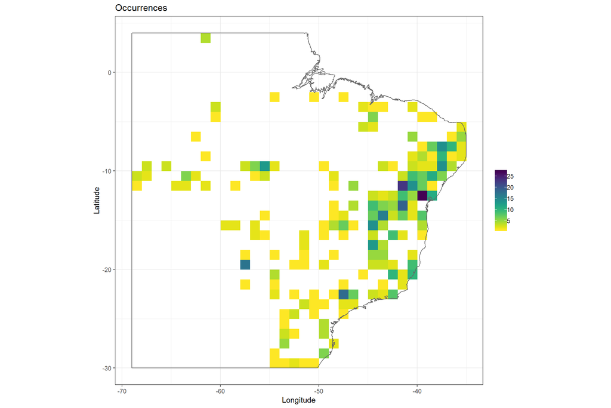

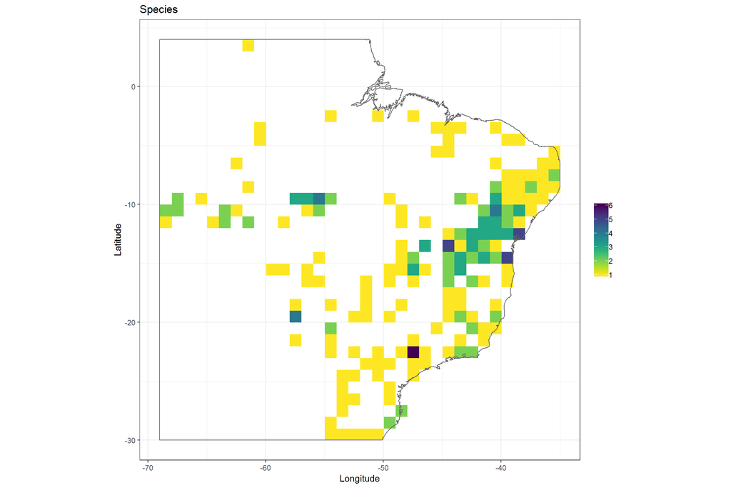

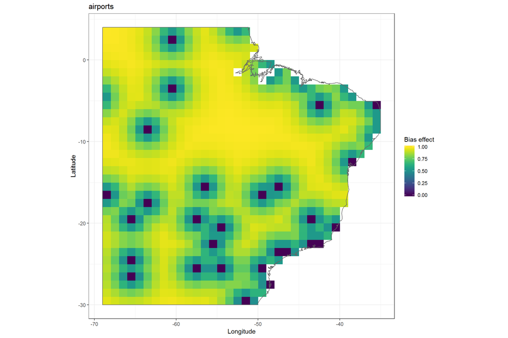

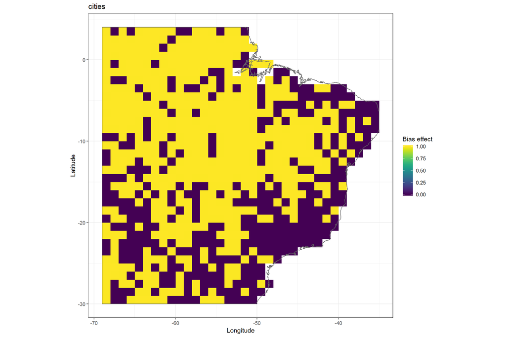

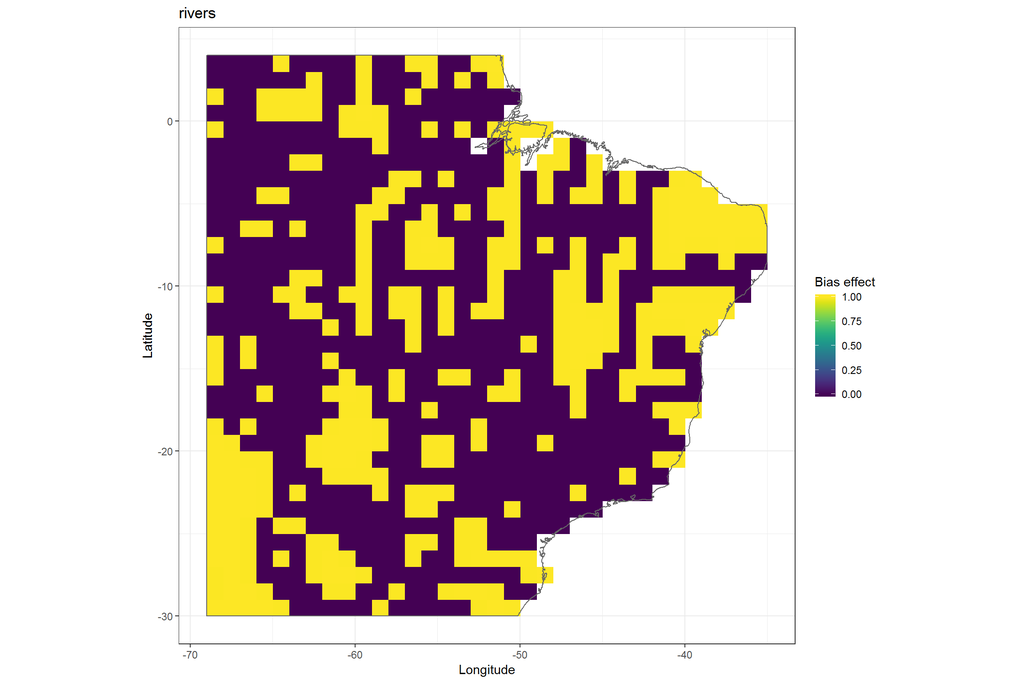

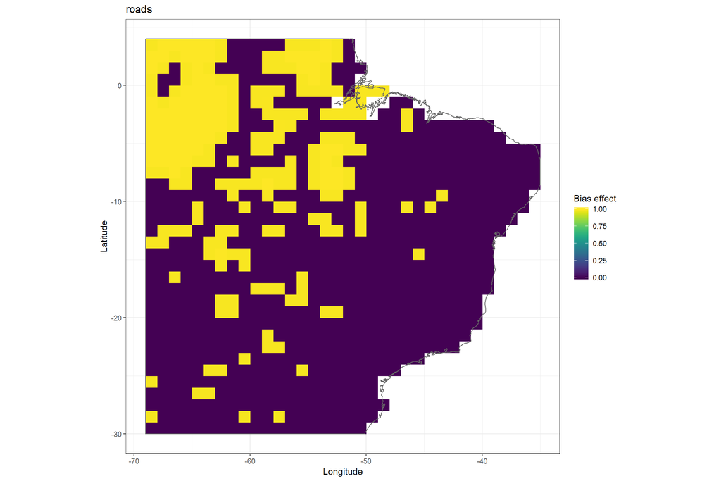

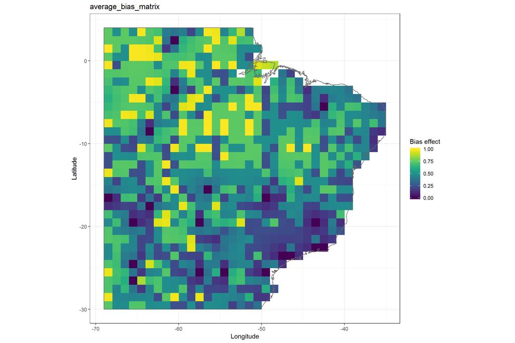

```
## Number of occurences:  686
## Number of species:  13
## Raster resolution:  1
## Distance binsize:  1e+05
## Convexhull:  FALSE
## Geographic extent:
## class       : Extent
## xmin        : -69
## xmax        : -35
## ymin        : -30
## ymax        : 4
## Bias effect at distance:
##          0        10000
## airports 0 6.980913e-05
## cities   0 5.712649e-04
## rivers   0 5.712649e-04
## roads    0 4.443454e-04
```

```r
# summarize results
summary(bias.out)

# Visualize
plot(bias.out)
```

## 4. Explore `?SamplingBias` and try to change the relevant arguments to improve the results. Summarize and visualize again.

```r
bias.det <- SamplingBias(x = occ, res = 0.1)

# summarize results
summary(bias.det)

# Visualize
par(mfrow = c(3, 2))
plot(bias.det)
```

[output not shown]

## 5. Explore the Bio-Dem app to explore the effect of political factos on data collections in your group.

http://bio-dem.surge.sh/